# Topic: Employee Churn Prediction Model

## 1. Introduction

An employee churn can be defined as when an employee leaves an organisation. Employee turnover is a costly problem for many companies, as the cost of replacing that employee can be quite large. A study by Centre for American Progress found that, on an average, companies pay about 1/5th of an employee’s salary to replace that employee. This cost can also significantly increase if executives or highest paid employees are to be replaced. This is due to the amount of time spent to interview, and find a replacement, sign-on bonuses and loss of productivity for several months while the employee gets accustomed to the new role.

### Problem Statement

We will be conducting exploratory and predictive analysis on the employee data from IBM HR Analytics and gather insights on:

1. What is the likelihood of an active employee leaving the company?
2. What are the key indicators of an employee leaving the company?
3. What strategies can be adopted based on the results to improve employee retention?

### Audience

The audience for this project will be the employers. Employers can make use of this model to check the key indicators which are affecting an employee to leave the organization. They can also make retention plans accordingly to eradicate the risk of employees leaving their companies.

## 2. Dataset

The dataset that we have taken is sourced from IBM HR Analytics which contains employee data with various information about the employees. This dataset helps us understand the main drivers of employee churn.It is found that employee churn will be affected by age, tenure, salary, job satisfaction, working conditions, growth potential, and employee’s perception of fairness, gender and education and promotion in the past 5 years.

### Importing Packages

```python
# importing libraries for data handling and analysis
import pandas as pd
from pandas.plotting import scatter_matrix
from pandas import ExcelWriter
from pandas import ExcelFile
from openpyxl import load_workbook
import numpy as np
from scipy.stats import norm, skew
from scipy import stats
import statsmodels.api as sm
```

```python
# importing libraries for data visualisations
import seaborn as sns
from matplotlib import pyplot
import matplotlib.pyplot as plt
import matplotlib.pylab as pylab
import matplotlib
%matplotlib inline
color = sns.color_palette()
from IPython.display import display
pd.options.display.max_columns = None
```

```python
# sklearn modules for preprocessing
from sklearn.preprocessing import OneHotEncoder, LabelEncoder
# from imblearn.over_sampling import SMOTE  # SMOTE
# sklearn modules for ML model selection
from sklearn.model_selection import train_test_split  # import 'train_test_split'
from sklearn.model_selection import GridSearchCV
from sklearn.model_selection import RandomizedSearchCV
from sklearn.model_selection import ShuffleSplit
from sklearn.model_selection import KFold
from sklearn.model_selection import cross_val_score

# Libraries for data modelling
from sklearn import svm, tree, linear_model, neighbors
from sklearn import naive_bayes, ensemble, discriminant_analysis, gaussian_process
from sklearn.linear_model import LogisticRegression
from sklearn.tree import DecisionTreeClassifier
from sklearn.neighbors import KNeighborsClassifier
from sklearn.discriminant_analysis import LinearDiscriminantAnalysis
from sklearn.naive_bayes import GaussianNB
from sklearn.svm import SVC
from sklearn.neighbors import KNeighborsClassifier
from xgboost import XGBClassifier
from sklearn.ensemble import RandomForestClassifier

# Common sklearn Model Helpers
from sklearn import feature_selection
from sklearn import model_selection
from sklearn import metrics
# from sklearn.datasets import make_classification

# sklearn modules for performance metrics
from sklearn.metrics import confusion_matrix, classification_report, precision_recall_curve
from sklearn.metrics import auc, roc_auc_score, roc_curve, recall_score, log_loss
from sklearn.metrics import f1_score, accuracy_score, roc_auc_score, make_scorer
from sklearn.metrics import average_precision_score
```

### Importing dataset

```python
df_sourcefile = pd.read_excel(
    'Desktop/WA_Fn-UseC_-HR-Employee-Attrition.xlsx', sheet_name=0)
print("Shape of dataframe is: {}".format(df_sourcefile.shape))
```

```
Shape of dataframe is: (1470, 30)
```

## 3. Cleaning the dataset

Let us first check the variables and values in the dataset.

```python
df_sourcefile.columns
```

```
Index(['Age', 'Attrition', 'BusinessTravel', 'DailyRate', 'Department',
       'DistanceFromHome', 'Education', 'EducationField', 'EmployeeCount',
       'EmployeeNumber', 'EnvironmentSatisfaction', 'Gender', 'HourlyRate',
       'JobInvolvement', 'JobLevel', 'JobRole', 'JobSatisfaction',
       'MaritalStatus', 'MonthlyIncome', 'MonthlyRate', 'NumCompaniesWorked',
       'Over18', 'OverTime', 'PercentSalaryHike', 'StandardHours',
       'TotalWorkingYears', 'WorkLifeBalance', 'YearsAtCompany',
       'YearsInCurrentRole', 'YearsSinceLastPromotion'],
      dtype='object')
```

```python
df_sourcefile.head()
```

|  | Age | Attrition | BusinessTravel | DailyRate | Department | DistanceFromHome | Education | EducationField | EmployeeCount | EmployeeNumber | EnvironmentSatisfaction | Gender | HourlyRate | JobInvolvement | JobLevel | JobRole | JobSatisfaction | MaritalStatus | MonthlyIncome | MonthlyRate | NumCompaniesWorked | Over18 | OverTime | PercentSalaryHike | StandardHours | TotalWorkingYears | WorkLifeBalance | YearsAtCompany | YearsInCurrentRole | … |
| --- | --- | --- | --- | --- | --- | --- | --- | --- | --- | --- | --- | --- | --- | --- | --- | --- | --- | --- | --- | --- | --- | --- | --- | --- | --- | --- | --- | --- | --- | --- |
| 0 | 41 | Yes | Travel_Rarely | 1102 | Sales | 1 | 2 | Life Sciences | 1 | 1 | 2 | Female | 94 | 3 | 2 | Sales Executive | 4 | Single | 5993 | 19479 | 8 | Y | Yes | 11 | 80 | 8 | 1 | 6 | 4 | … |
| 1 | 49 | No | Travel_Frequently | 279 | Research & Development | 8 | 1 | Life Sciences | 1 | 2 | 3 | Male | 61 | 2 | 2 | Research Scientist | 2 | Married | 5130 | 24907 | 1 | Y | No | 23 | 80 | 10 | 3 | 10 | 7 | … |
| 2 | 37 | Yes | Travel_Rarely | 1373 | Research & Development | 2 | 2 | Other | 1 | 4 | 4 | Male | 92 | 2 | 1 | Laboratory Technician | 3 | Single | 2090 | 2396 | 6 | Y | Yes | 15 | 80 | 7 | 3 | 0 | 0 | … |
| 3 | 33 | No | Travel_Frequently | 1392 | Research & Development | 3 | 4 | Life Sciences | 1 | 5 | 4 | Female | 56 | 3 | 1 | Research Scientist | 3 | Married | 2909 | 23159 | 1 | Y | Yes | 11 | 80 | 8 | 3 | 8 | 7 | … |
| 4 | 27 | No | Travel_Rarely | 591 | Research & Development | 2 | 1 | Medical | 1 | 7 | 1 | Male | 40 | 3 | 1 | Laboratory Technician | 2 | Married | 3468 | 16632 | 9 | Y | No | 12 | 80 | 6 | 3 | 2 | 2 | … |

```python
df_sourcefile.columns.to_series().groupby(df_sourcefile.dtypes).groups
```

```
{dtype('int64'): Index(['Age', 'DailyRate', 'DistanceFromHome', 'Education', 'EmployeeCount',
        'EmployeeNumber', 'EnvironmentSatisfaction', 'HourlyRate',
        'JobInvolvement', 'JobLevel', 'JobSatisfaction', 'MonthlyIncome',
        'MonthlyRate', 'NumCompaniesWorked', 'PercentSalaryHike',
        'StandardHours', 'TotalWorkingYears', 'WorkLifeBalance',
        'YearsAtCompany', 'YearsInCurrentRole', 'YearsSinceLastPromotion'],
       dtype='object'),
 dtype('O'): Index(['Attrition', 'BusinessTravel', 'Department', 'EducationField', 'Gender',
        'JobRole', 'MaritalStatus', 'Over18', 'OverTime'],
       dtype='object')}
```

#### From the above data, we can see that the data is differentiated into numerical and non-numerical categories.

## i) To check the format

Since the data does not contain any time series, we are not going to fix the format. We will be using the data as it is without formatting because it is not required.

## ii) To check for null values

```python
df_sourcefile.info() #displays variables, data types, and null objects if any.
```

```
<class 'pandas.core.frame.DataFrame'>
RangeIndex: 1470 entries, 0 to 1469
Data columns (total 30 columns):
Age                        1470 non-null int64
Attrition                  1470 non-null object
BusinessTravel             1470 non-null object
DailyRate                  1470 non-null int64
Department                 1470 non-null object
DistanceFromHome           1470 non-null int64
Education                  1470 non-null int64
EducationField             1470 non-null object
EmployeeCount              1470 non-null int64
EmployeeNumber             1470 non-null int64
EnvironmentSatisfaction    1470 non-null int64
Gender                     1470 non-null object
HourlyRate                 1470 non-null int64
JobInvolvement             1470 non-null int64
JobLevel                   1470 non-null int64
JobRole                    1470 non-null object
JobSatisfaction            1470 non-null int64
MaritalStatus              1470 non-null object
MonthlyIncome              1470 non-null int64
MonthlyRate                1470 non-null int64
NumCompaniesWorked         1470 non-null int64
Over18                     1470 non-null object
OverTime                   1470 non-null object
PercentSalaryHike          1470 non-null int64
StandardHours              1470 non-null int64
TotalWorkingYears          1470 non-null int64
WorkLifeBalance            1470 non-null int64
YearsAtCompany             1470 non-null int64
YearsInCurrentRole         1470 non-null int64
YearsSinceLastPromotion    1470 non-null int64
dtypes: int64(21), object(9)
memory usage: 344.6+ KB
```

#### We can see that there are no null values in the dataset.

## iii) Checking for duplicate values

We are checking for duplicate values if there are any.

```python
df_duplicate = df_sourcefile[df_sourcefile.duplicated()]
```

## 4. Exploratory Data Analysis

We will group the data based on the number of employees who left the company or are still actively working.

```python
left = df_sourcefile.groupby('Attrition')
left.mean()
```

| Attrition | Age | DailyRate | DistanceFromHome | Education | EmployeeCount | EmployeeNumber | EnvironmentSatisfaction | HourlyRate | JobInvolvement | JobLevel | JobSatisfaction | MonthlyIncome | MonthlyRate | NumCompaniesWorked | PercentSalaryHike | StandardHours | TotalWorkingYears | WorkLifeBalance | YearsAtCompany | YearsInCurrentRole | YearsSinceLastPromotion |
| --- | --- | --- | --- | --- | --- | --- | --- | --- | --- | --- | --- | --- | --- | --- | --- | --- | --- | --- | --- | --- | --- |
| No | 37.561233 | 812.504461 | 8.915653 | 2.927007 | 1.0 | 1027.656123 | 2.771290 | 65.952149 | 2.770479 | 2.145985 | 2.778589 | 6832.739659 | 14265.779400 | 2.645580 | 15.231144 | 80.0 | 11.862936 | 2.781022 | 7.369019 | 4.484185 | 2.234388 |
| Yes | 33.607595 | 750.362869 | 10.632911 | 2.839662 | 1.0 | 1010.345992 | 2.464135 | 65.573840 | 2.518987 | 1.637131 | 2.468354 | 4787.092827 | 14559.308017 | 2.940928 | 15.097046 | 80.0 | 8.244726 | 2.658228 | 5.130802 | 2.902954 | 1.945148 |

We will first use describe( ) function to find out the numerical features overview. We will use this data to perform Exploratory Data Analysis.

```python
df_sourcefile.describe()
```

|  | Age | DailyRate | DistanceFromHome | Education | EmployeeCount | EmployeeNumber | EnvironmentSatisfaction | HourlyRate | JobInvolvement | JobLevel | JobSatisfaction | MonthlyIncome | MonthlyRate | NumCompaniesWorked | PercentSalaryHike | StandardHours | TotalWorkingYears | WorkLifeBalance | YearsAtCompany | YearsInCurrentRole | YearsSinceLastPromotion |
| --- | --- | --- | --- | --- | --- | --- | --- | --- | --- | --- | --- | --- | --- | --- | --- | --- | --- | --- | --- | --- | --- |
| count | 1470.000000 | 1470.000000 | 1470.000000 | 1470.000000 | 1470.0 | 1470.000000 | 1470.000000 | 1470.000000 | 1470.000000 | 1470.000000 | 1470.000000 | 1470.000000 | 1470.000000 | 1470.000000 | 1470.000000 | 1470.0 | 1470.000000 | 1470.000000 | 1470.000000 | 1470.000000 | 1470.000000 |
| mean | 36.923810 | 802.485714 | 9.192517 | 2.912925 | 1.0 | 1024.865306 | 2.721769 | 65.891156 | 2.729932 | 2.063946 | 2.728571 | 6502.931293 | 14313.103401 | 2.693197 | 15.209524 | 80.0 | 11.279592 | 2.761224 | 7.008163 | 4.229252 | 2.187755 |
| std | 9.135373 | 403.509100 | 8.106864 | 1.024165 | 0.0 | 602.024335 | 1.093082 | 20.329428 | 0.711561 | 1.106940 | 1.102846 | 4707.956783 | 7117.786044 | 2.498009 | 3.659938 | 0.0 | 7.780782 | 0.706476 | 6.126525 | 3.623137 | 3.222430 |
| min | 18.000000 | 102.000000 | 1.000000 | 1.000000 | 1.0 | 1.000000 | 1.000000 | 30.000000 | 1.000000 | 1.000000 | 1.000000 | 1009.000000 | 2094.000000 | 0.000000 | 11.000000 | 80.0 | 0.000000 | 1.000000 | 0.000000 | 0.000000 | 0.000000 |
| 25% | 30.000000 | 465.000000 | 2.000000 | 2.000000 | 1.0 | 491.250000 | 2.000000 | 48.000000 | 2.000000 | 1.000000 | 2.000000 | 2911.000000 | 8047.000000 | 1.000000 | 12.000000 | 80.0 | 6.000000 | 2.000000 | 3.000000 | 2.000000 | 0.000000 |
| 50% | 36.000000 | 802.000000 | 7.000000 | 3.000000 | 1.0 | 1020.500000 | 3.000000 | 66.000000 | 3.000000 | 2.000000 | 3.000000 | 4919.000000 | 14235.500000 | 2.000000 | 14.000000 | 80.0 | 10.000000 | 3.000000 | 5.000000 | 3.000000 | 1.000000 |
| 75% | 43.000000 | 1157.000000 | 14.000000 | 4.000000 | 1.0 | 1555.750000 | 4.000000 | 83.750000 | 3.000000 | 3.000000 | 4.000000 | 8379.000000 | 20461.500000 | 4.000000 | 18.000000 | 80.0 | 15.000000 | 3.000000 | 9.000000 | 7.000000 | 3.000000 |
| max | 60.000000 | 1499.000000 | 29.000000 | 5.000000 | 1.0 | 2068.000000 | 4.000000 | 100.000000 | 4.000000 | 5.000000 | 4.000000 | 19999.000000 | 26999.000000 | 9.000000 | 25.000000 | 80.0 | 40.000000 | 4.000000 | 40.000000 | 18.000000 | 15.000000 |

We have checked for the mean, minimum, maximum, standard deviation values for the information provided in each column. We have also got the Q1, Q2, Q3. This way we can also figure out if there are any outliers in the data using these values.

### Now we will plot the histograms using the employee's information.

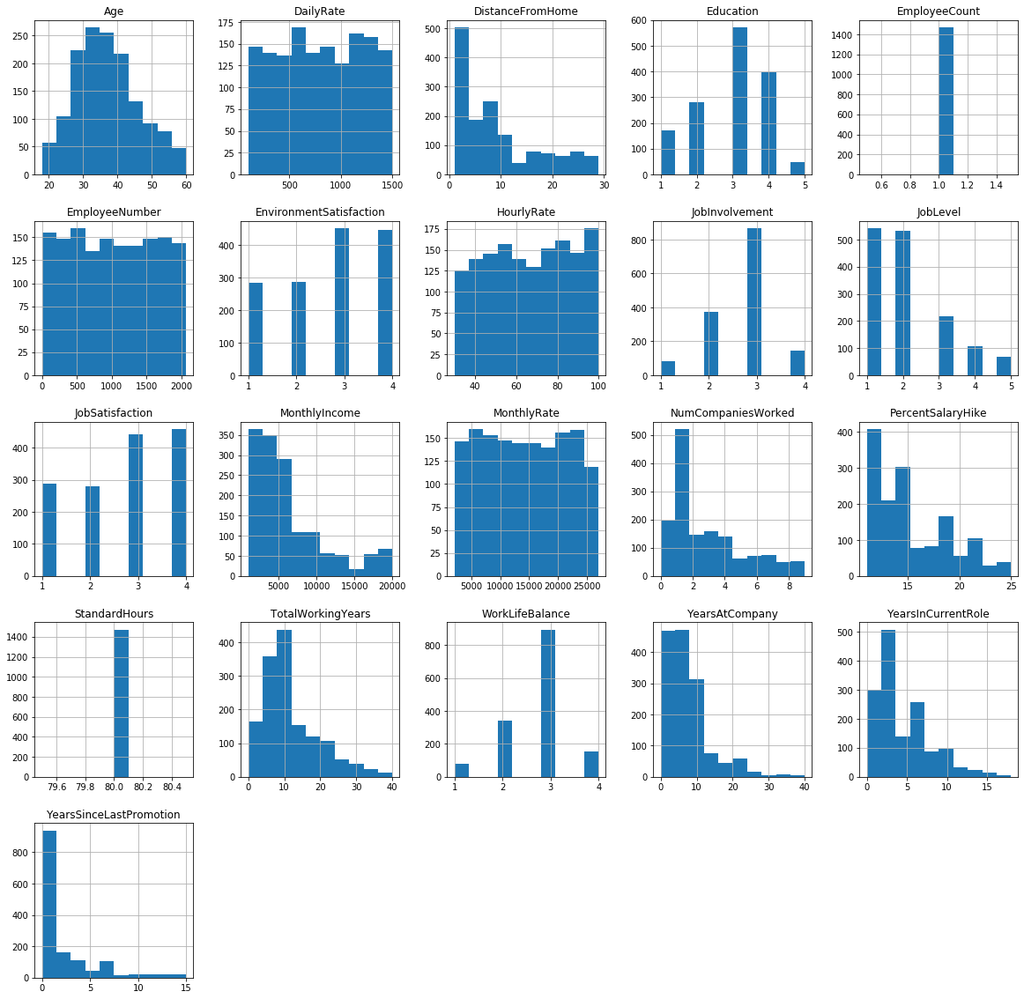

```python
df_sourcefile.hist(figsize=(20,20))
plt.show()
```

Few observations based on Exploratory Data Analysis:

a) Most of the histograms seem tail-heavy, and several distributions are right-skewed (e.g. MonthlyIncome, DistanceFromHome, YearsAtCompany). Data transformation methods may be required to approach a normal distribution before we fit a model to the data.

b) Age distribution is a slightly right-skewed normal distribution. Most of the staff are aged between 25 and 45 years old.

c) EmployeeCount and StandardHours are constant values for all employees. They're likely to be redundant features.

d) Employee Number is likely to be a unique identifier for employees given the feature's have few uniform structures but not all of them are uniform.

## 5. Visualization

We will be visualizing the data based on the unique attribute, No. of Employees, due to it's uniform structure.

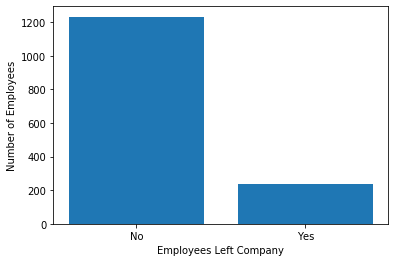

```python
left_count=df_sourcefile.groupby('Attrition').count()
plt.bar(left_count.index.values, left_count['JobSatisfaction'])
plt.xlabel('Employees Left Company')
plt.ylabel('Number of Employees')
plt.show()
```

```python
df_sourcefile.Attrition.value_counts()
```

```
No     1233
Yes     237
Name: Attrition, dtype: int64
```

#### Hence, the number of people who left on the basis of job satisfaction level is 237 and 1233 stayed. This accounts to 16.1% of the total.

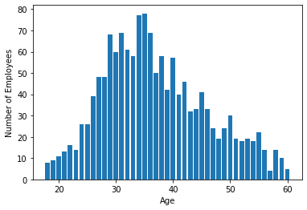

```python
num_projects=df_sourcefile.groupby('Age').count()
plt.bar(num_projects.index.values, num_projects['JobSatisfaction'])
plt.xlabel('Age')
plt.ylabel('Number of Employees')
plt.show()
```

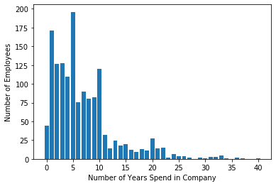

```python
time_spent=df_sourcefile.groupby('YearsAtCompany').count()
plt.bar(time_spent.index.values, time_spent['JobSatisfaction'])
plt.xlabel('Number of Years Spend in Company')
plt.ylabel('Number of Employees')
plt.show()
```

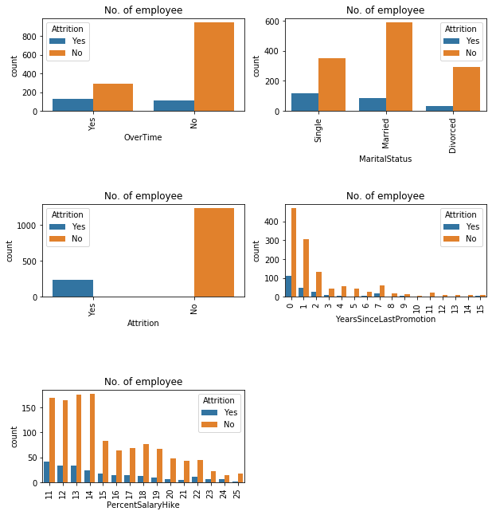

```python
features=['OverTime','MaritalStatus','Attrition', 'YearsSinceLastPromotion','PercentSalaryHike']

fig=plt.subplots(figsize=(10,15))
for i, j in enumerate(features):
    plt.subplot(4, 2, i+1)
    plt.subplots_adjust(hspace = 1.0)
    sns.countplot(x=j,data = df_sourcefile, hue='Attrition')
    plt.xticks(rotation=90)
    plt.title("No. of employee")
```

```python
print("Percentage of Current Employees is {:.1f}% and of Ex-employees is: {:.1f}%".format(
    df_sourcefile[df_sourcefile['Attrition'] == 'No'].shape[0] / df_sourcefile.shape[0]*100,
    df_sourcefile[df_sourcefile['Attrition'] == 'Yes'].shape[0] / df_sourcefile.shape[0]*100))
```

```
Percentage of Current Employees is 83.9% and of Ex-employees is: 16.1%
```

## 6. Statistical Analyses

It’s the science of collecting, exploring and presenting large amounts of data to discover underlying patterns and trends.

## 6.1 Target Variable - Attrition

We are trying to predict the value of the feature 'Attrition' by using other related features associated with the employee's personal and professional history.

## 6.2 Correlation

We have to figure out the most significant correlations. We will be performing analysis to check the most positive correlations and most negative correlations. After this, we will plot a heat map to visualize correlation between attrition and these factors

```python
#code to find out the correlations between various factors

df_HR_trans = df_sourcefile.copy()
df_HR_trans['Target'] = df_HR_trans['Attrition'].apply(
    lambda x: 0 if x == 'No' else 1)
df_HR_trans = df_HR_trans.drop(
    ['Attrition', 'EmployeeCount', 'EmployeeNumber', 'StandardHours', 'Over18'], axis=1)
correlations = df_HR_trans.corr()['Target'].sort_values()
print('Most Positive Correlations: \n', correlations.tail(4))
print('\nMost Negative Correlations: \n', correlations.head(4))
```

```
Most Positive Correlations:
 MonthlyRate           0.015170
NumCompaniesWorked    0.043494
DistanceFromHome      0.077924
Target                1.000000
Name: Target, dtype: float64

Most Negative Correlations:
 TotalWorkingYears    -0.171063
JobLevel             -0.169105
YearsInCurrentRole   -0.160545
MonthlyIncome        -0.159840
Name: Target, dtype: float64
```

### Plotting a graph to show these correlations

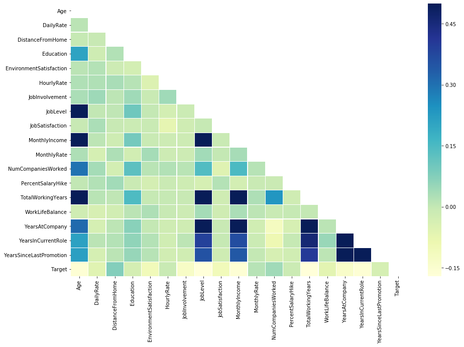

```python
# Calculating correlations
corr = df_HR_trans.corr()
mask = np.zeros_like(corr)
mask[np.triu_indices_from(mask)] = True
# Heatmap
plt.figure(figsize=(15, 10))
sns.heatmap(corr,
            vmax=.5,
            mask=mask,
            # annot=True, fmt='.2f',
            linewidths=.2, cmap="YlGnBu")
```

As shown above, "Monthly Rate", "Number of Companies Worked" and "Distance From Home" are positively correlated to Attrition; while "Total Working Years", "Job Level", and "Years In Current Role" are negatively correlated to Attrition.

## 6.3 Encoding

Machine Learning algorithms can typically only have numerical values as their predictor variables. Hence, Label Encoding is necessary as they encode categorical labels with numerical values. We will use both Lable Encoding and One-Hot Encoding to avoid the usage of unique values.

```python
from sklearn.preprocessing import LabelEncoder, OneHotEncoder
# Creating a label encoder object
le = LabelEncoder()
```

```python
print(df_sourcefile.shape)
df_sourcefile.head()
```

```
(1470, 30)
```

|  | Age | Attrition | BusinessTravel | DailyRate | Department | DistanceFromHome | Education | EducationField | EmployeeCount | EmployeeNumber | EnvironmentSatisfaction | Gender | HourlyRate | JobInvolvement | JobLevel | JobRole | JobSatisfaction | MaritalStatus | MonthlyIncome | MonthlyRate | NumCompaniesWorked | Over18 | OverTime | PercentSalaryHike | StandardHours | TotalWorkingYears | WorkLifeBalance | YearsAtCompany | YearsInCurrentRole | … |
| --- | --- | --- | --- | --- | --- | --- | --- | --- | --- | --- | --- | --- | --- | --- | --- | --- | --- | --- | --- | --- | --- | --- | --- | --- | --- | --- | --- | --- | --- | --- |
| 0 | 41 | Yes | Travel_Rarely | 1102 | Sales | 1 | 2 | Life Sciences | 1 | 1 | 2 | Female | 94 | 3 | 2 | Sales Executive | 4 | Single | 5993 | 19479 | 8 | Y | Yes | 11 | 80 | 8 | 1 | 6 | 4 | … |
| 1 | 49 | No | Travel_Frequently | 279 | Research & Development | 8 | 1 | Life Sciences | 1 | 2 | 3 | Male | 61 | 2 | 2 | Research Scientist | 2 | Married | 5130 | 24907 | 1 | Y | No | 23 | 80 | 10 | 3 | 10 | 7 | … |
| 2 | 37 | Yes | Travel_Rarely | 1373 | Research & Development | 2 | 2 | Other | 1 | 4 | 4 | Male | 92 | 2 | 1 | Laboratory Technician | 3 | Single | 2090 | 2396 | 6 | Y | Yes | 15 | 80 | 7 | 3 | 0 | 0 | … |
| 3 | 33 | No | Travel_Frequently | 1392 | Research & Development | 3 | 4 | Life Sciences | 1 | 5 | 4 | Female | 56 | 3 | 1 | Research Scientist | 3 | Married | 2909 | 23159 | 1 | Y | Yes | 11 | 80 | 8 | 3 | 8 | 7 | … |
| 4 | 27 | No | Travel_Rarely | 591 | Research & Development | 2 | 1 | Medical | 1 | 7 | 1 | Male | 40 | 3 | 1 | Laboratory Technician | 2 | Married | 3468 | 16632 | 9 | Y | No | 12 | 80 | 6 | 3 | 2 | 2 | … |

```python
# Label Encoding will be used for columns with 2 or less unique values
le_count = 0
for col in df_sourcefile.columns[1:]:
    if df_sourcefile[col].dtype == 'object':
        if len(list(df_sourcefile[col].unique())) <= 2:
            le.fit(df_sourcefile[col])
            df_sourcefile[col] = le.transform(df_sourcefile[col])
            le_count += 1
print('{} columns were label encoded.'.format(le_count))
```

```
4 columns were label encoded.
```

```python
# convert rest of categorical variable into dummy
df_sourcefile = pd.get_dummies(df_sourcefile, drop_first=True)
```

```python
print(df_sourcefile.shape)
df_sourcefile.head()
```

```
(1470, 44)
```

|  | Age | Attrition | DailyRate | DistanceFromHome | Education | EmployeeCount | EmployeeNumber | EnvironmentSatisfaction | Gender | HourlyRate | JobInvolvement | JobLevel | JobSatisfaction | MonthlyIncome | MonthlyRate | NumCompaniesWorked | Over18 | OverTime | PercentSalaryHike | StandardHours | TotalWorkingYears | WorkLifeBalance | YearsAtCompany | YearsInCurrentRole | YearsSinceLastPromotion | BusinessTravel_Travel_Frequently | BusinessTravel_Travel_Rarely | Department_Research & Development | Department_Sales | … |
| --- | --- | --- | --- | --- | --- | --- | --- | --- | --- | --- | --- | --- | --- | --- | --- | --- | --- | --- | --- | --- | --- | --- | --- | --- | --- | --- | --- | --- | --- | --- |
| 0 | 41 | 1 | 1102 | 1 | 2 | 1 | 1 | 2 | 0 | 94 | 3 | 2 | 4 | 5993 | 19479 | 8 | 0 | 1 | 11 | 80 | 8 | 1 | 6 | 4 | 0 | 0 | 1 | 0 | 1 | … |
| 1 | 49 | 0 | 279 | 8 | 1 | 1 | 2 | 3 | 1 | 61 | 2 | 2 | 2 | 5130 | 24907 | 1 | 0 | 0 | 23 | 80 | 10 | 3 | 10 | 7 | 1 | 1 | 0 | 1 | 0 | … |
| 2 | 37 | 1 | 1373 | 2 | 2 | 1 | 4 | 4 | 1 | 92 | 2 | 1 | 3 | 2090 | 2396 | 6 | 0 | 1 | 15 | 80 | 7 | 3 | 0 | 0 | 0 | 0 | 1 | 1 | 0 | … |
| 3 | 33 | 0 | 1392 | 3 | 4 | 1 | 5 | 4 | 0 | 56 | 3 | 1 | 3 | 2909 | 23159 | 1 | 0 | 1 | 11 | 80 | 8 | 3 | 8 | 7 | 3 | 1 | 0 | 1 | 0 | … |
| 4 | 27 | 0 | 591 | 2 | 1 | 1 | 7 | 1 | 1 | 40 | 3 | 1 | 2 | 3468 | 16632 | 9 | 0 | 0 | 12 | 80 | 6 | 3 | 2 | 2 | 2 | 0 | 1 | 1 | 0 | … |

## 6.4 Scaling the data

```python
# import MinMaxScaler
from sklearn.preprocessing import MinMaxScaler
scaler = MinMaxScaler(feature_range=(0, 5))
HR_col = list(df_sourcefile.columns)
HR_col.remove('Attrition')
for col in HR_col:
    df_sourcefile[col] = df_sourcefile[col].astype(float)
    df_sourcefile[[col]] = scaler.fit_transform(df_sourcefile[[col]])
df_sourcefile['Attrition'] = pd.to_numeric(df_sourcefile['Attrition'], downcast='float')
df_sourcefile.head()
```

|  | Age | Attrition | DailyRate | DistanceFromHome | Education | EmployeeCount | EmployeeNumber | EnvironmentSatisfaction | Gender | HourlyRate | JobInvolvement | JobLevel | JobSatisfaction | MonthlyIncome | MonthlyRate | NumCompaniesWorked | Over18 | OverTime | PercentSalaryHike | StandardHours | TotalWorkingYears | WorkLifeBalance | YearsAtCompany | YearsInCurrentRole | YearsSinceLastPromotion | BusinessTravel_Travel_Frequently | BusinessTravel_Travel_Rarely | Department_Research & Development | Department_Sales | … |
| --- | --- | --- | --- | --- | --- | --- | --- | --- | --- | --- | --- | --- | --- | --- | --- | --- | --- | --- | --- | --- | --- | --- | --- | --- | --- | --- | --- | --- | --- | --- |
| 0 | 2.738095 | 1.0 | 3.579098 | 0.000000 | 1.25 | 0.0 | 0.000000 | 1.666667 | 0.0 | 4.571429 | 3.333333 | 1.25 | 5.000000 | 1.312270 | 3.490263 | 4.444444 | 0.0 | 5.0 | 0.000000 | 0.0 | 1.000 | 0.000000 | 0.75 | 1.111111 | 0.000000 | 0.0 | 5.0 | 0.0 | 5.0 | … |
| 1 | 3.690476 | 0.0 | 0.633500 | 1.250000 | 0.00 | 0.0 | 0.002419 | 3.333333 | 5.0 | 2.214286 | 1.666667 | 1.25 | 1.666667 | 1.085045 | 4.580004 | 0.555556 | 0.0 | 0.0 | 4.285714 | 0.0 | 1.250 | 3.333333 | 1.25 | 1.944444 | 0.333333 | 5.0 | 0.0 | 5.0 | 0.0 | … |
| 2 | 2.261905 | 1.0 | 4.549034 | 0.178571 | 1.25 | 0.0 | 0.007257 | 5.000000 | 5.0 | 4.428571 | 1.666667 | 0.00 | 3.333333 | 0.284623 | 0.060630 | 3.333333 | 0.0 | 5.0 | 1.428571 | 0.0 | 0.875 | 3.333333 | 0.00 | 0.000000 | 0.000000 | 0.0 | 5.0 | 5.0 | 0.0 | … |
| 3 | 1.785714 | 0.0 | 4.617037 | 0.357143 | 3.75 | 0.0 | 0.009676 | 5.000000 | 0.0 | 1.857143 | 3.333333 | 0.00 | 3.333333 | 0.500263 | 4.229070 | 0.555556 | 0.0 | 5.0 | 0.000000 | 0.0 | 1.000 | 3.333333 | 1.00 | 1.944444 | 1.000000 | 5.0 | 0.0 | 5.0 | 0.0 | … |
| 4 | 1.071429 | 0.0 | 1.750179 | 0.178571 | 0.00 | 0.0 | 0.014514 | 0.000000 | 5.0 | 0.714286 | 3.333333 | 0.00 | 1.666667 | 0.647446 | 2.918691 | 5.000000 | 0.0 | 0.0 | 0.357143 | 0.0 | 0.750 | 3.333333 | 0.25 | 0.555556 | 0.666667 | 0.0 | 5.0 | 5.0 | 0.0 | … |

MinMaxScaler essentially shrinks the range such that the range is now between 0 and n. Machine Learning algorithms perform better when input numerical variables fall within a similar scale. In this case, we are scaling between 0 and 5.

```python
print('Size of Full Encoded Dataset: {}'. format(df_sourcefile.shape))
```

```
Size of Full Encoded Dataset: (1470, 44)
```

## 6.5 Splitting data into training and testing set

We are doing this to apply Baseline algorithms like Logistic Regression, Random Forest, SVM, KNN, Decision Tree Classifier, Gaussian NB before we move on to the solutions.

```python
# assign the target to a new dataframe and convert it to a numerical feature
#df_target = df_sourcefile[['Attrition']].copy()
target = df_sourcefile['Attrition'].copy()
type(target)
```

```
pandas.core.series.Series
```

Now, we are going to remove the target feature and redundant features from the dataset.

```python
df_sourcefile.drop(['Attrition', 'EmployeeCount', 'EmployeeNumber',
            'StandardHours', 'Over18'], axis=1, inplace=True)
print('Size of Full dataset is: {}'.format(df_sourcefile.shape))
```

```
Size of Full dataset is: (1470, 39)
```

```python
# Since we have class imbalance (i.e. more employees with turnover=0 than turnover=1)
# let's use stratify=y to maintain the same ratio as in the training dataset when splitting the dataset
X_train, X_test, y_train, y_test = train_test_split(df_sourcefile,
                                                    target,
                                                    test_size=0.25,
                                                    random_state=7,
                                                    stratify=target)
print("Number transactions X_train dataset: ", X_train.shape)
print("Number transactions y_train dataset: ", y_train.shape)
print("Number transactions X_test dataset: ", X_test.shape)
print("Number transactions y_test dataset: ", y_test.shape)
```

```
Number transactions X_train dataset:  (1102, 39)
Number transactions y_train dataset:  (1102,)
Number transactions X_test dataset:  (368, 39)
Number transactions y_test dataset:  (368,)
```

## 7. Baseline Algorithms

We are going to use baseline algorithms like Logistic Regression, Random Forest, SVM, KNN, Decision Tree Classifier, Gaussian NB before we move on to buidling Machine Learning Model.

```python
# selection of algorithms to consider and set performance measure
models = []
models.append(('Logistic Regression', LogisticRegression(solver='liblinear', random_state=7,
                                                         class_weight='balanced')))
models.append(('Random Forest', RandomForestClassifier(
    n_estimators=100, random_state=7)))
models.append(('SVM', SVC(gamma='auto', random_state=7)))
models.append(('KNN', KNeighborsClassifier()))
models.append(('Decision Tree Classifier',
               DecisionTreeClassifier(random_state=7)))
models.append(('Gaussian NB', GaussianNB()))
```

Now we will evaluate each algorithm and get the standard deviation scores for all of them.

```python
acc_results = []
auc_results = []
names = []
# set table to table to populate with performance results
col = ['Algorithm', 'ROC AUC Mean', 'ROC AUC STD',
       'Accuracy Mean', 'Accuracy STD']
df_results = pd.DataFrame(columns=col)
i = 0
# evaluate each model using cross-validation
for name, model in models:
    kfold = model_selection.KFold(
        n_splits=10, random_state=7)  # 10-fold cross-validation

    cv_acc_results = model_selection.cross_val_score(  # accuracy scoring
        model, X_train, y_train, cv=kfold, scoring='accuracy')

    cv_auc_results = model_selection.cross_val_score(  # roc_auc scoring
        model, X_train, y_train, cv=kfold, scoring='roc_auc')

    acc_results.append(cv_acc_results)
    auc_results.append(cv_auc_results)
    names.append(name)
    df_results.loc[i] = [name,
                         round(cv_auc_results.mean()*100, 2),
                         round(cv_auc_results.std()*100, 2),
                         round(cv_acc_results.mean()*100, 2),
                         round(cv_acc_results.std()*100, 2)
                         ]
    i += 1
df_results.sort_values(by=['ROC AUC Mean'], ascending=False)
```

|  | Algorithm | ROC AUC Mean | ROC AUC STD | Accuracy Mean | Accuracy STD |
| --- | --- | --- | --- | --- | --- |
| 0 | Logistic Regression | 81.49 | 7.05 | 74.58 | 5.33 |
| 1 | Random Forest | 77.65 | 7.17 | 85.57 | 3.70 |
| 2 | SVM | 77.39 | 8.15 | 84.57 | 4.20 |
| 5 | Gaussian NB | 74.84 | 5.11 | 66.23 | 3.50 |
| 3 | KNN | 67.77 | 8.60 | 84.30 | 3.56 |
| 4 | Decision Tree Classifier | 58.64 | 5.46 | 76.13 | 3.44 |

#### We will compare all the algorithms by plotting them. First we will see Classification Accuracy. It is the number of correct predictions made as a ratio of all predictions made.

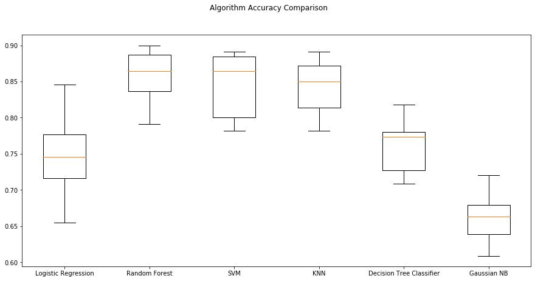

```python
#plotting the graph
fig = plt.figure(figsize=(15, 7))
fig.suptitle('Algorithm Accuracy Comparison')
ax = fig.add_subplot(111)
plt.boxplot(acc_results)
ax.set_xticklabels(names)
plt.show()
```

Next, Area under ROC Curve (or AUC for short) is a performance metric for binary classification problems. The AUC represents a model’s ability to discriminate between positive and negative classes. An area of 1.0 represents a model that made all predictions perfectly. An area of 0.5 represents a model as good as random.

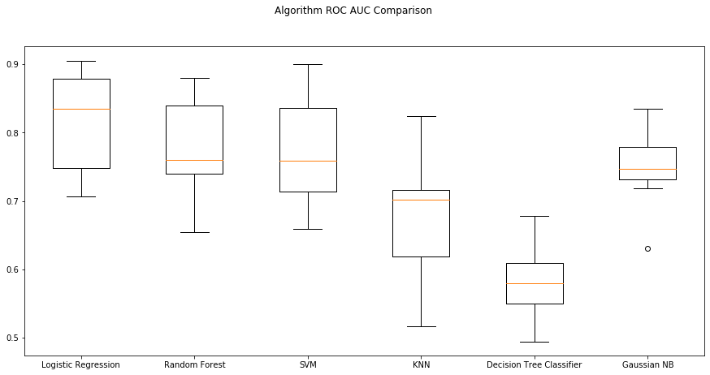

```python
fig = plt.figure(figsize=(15, 7))
fig.suptitle('Algorithm ROC AUC Comparison')
ax = fig.add_subplot(111)
plt.boxplot(auc_results)
ax.set_xticklabels(names)
plt.show()
```

#### Based on our ROC AUC comparison analysis, Logistic Regression and Random Forest show the highest mean AUC scores. We will shortlist these two algorithms for further analysis.

## 7.1 Logistic Regression

Logistic Regression is a Machine Learning classification algorithm that is used to predict the probability of a categorical dependent variable. Logistic Regression is classification algorithm that is not as sophisticated as the ensemble methods or boosted decision trees method. Hence, it provides us with a good benchmark.

We will train the Logistic Regression Model and estimate its AUC score.

```python
fold = model_selection.KFold(n_splits=10, random_state=7)
modelCV = LogisticRegression(solver='liblinear',
                             class_weight="balanced",
                             random_state=7)
scoring = 'roc_auc'
results = model_selection.cross_val_score(
    modelCV, X_train, y_train, cv=kfold, scoring=scoring)
print("AUC score (STD): %.2f (%.2f)" % (results.mean(), results.std()))
```

```
AUC score (STD): 0.81 (0.07)
```

### Optimization

GridSearchCV allows us to fine-tune hyper-parameters by searching over specified parameter values for an estimator.

```python
param_grid = {'C': np.arange(1e-03, 2, 0.01)} # hyper-parameter list to fine-tune
log_gs = GridSearchCV(LogisticRegression(solver='liblinear', # setting GridSearchCV
                                         class_weight="balanced",
                                         random_state=7),
                      iid=True,
                      return_train_score=True,
                      param_grid=param_grid,
                      scoring='roc_auc',
                      cv=10)

log_grid = log_gs.fit(X_train, y_train)
log_opt = log_grid.best_estimator_
results = log_gs.cv_results_

print('='*20)
print("best params: " + str(log_gs.best_estimator_))
print("best params: " + str(log_gs.best_params_))
print('best score:', log_gs.best_score_)
print('='*20)
```

```
====================
best params: LogisticRegression(C=0.011, class_weight='balanced', dual=False,
                   fit_intercept=True, intercept_scaling=1, l1_ratio=None,
                   max_iter=100, multi_class='warn', n_jobs=None, penalty='l2',
                   random_state=7, solver='liblinear', tol=0.0001, verbose=0,
                   warm_start=False)
best params: {'C': 0.011}
best score: 0.8162103200538617
====================
```

As shown above, the results from GridSearchCV provided us with fine-tuned hyper-parameter using ROC_AUC as the scoring metric.

```
Accuracy of Logistic Regression Classifier on test set: 74.73
```

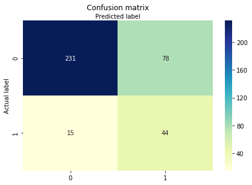

```python
## Confusion Matrix
cnf_matrix = metrics.confusion_matrix(y_test, log_opt.predict(X_test))
class_names=[0,1] # name  of classes
fig, ax = plt.subplots()
tick_marks = np.arange(len(class_names))
plt.xticks(tick_marks, class_names)
plt.yticks(tick_marks, class_names)
# create heatmap
sns.heatmap(pd.DataFrame(cnf_matrix), annot=True, cmap="YlGnBu" ,fmt='g')
ax.xaxis.set_label_position("top")
plt.tight_layout()
plt.title('Confusion matrix', y=1.1)
plt.ylabel('Actual label')
plt.xlabel('Predicted label')
print('Accuracy of Logistic Regression Classifier on test set: {:.2f}'.format(log_opt.score(X_test, y_test)*100))
```

From the above values, we can see that we have 231 + 44 correct predictions and 78+15 incorrect predictions which accounts to a total of 74.73% accuracy.

```python
# Classification report for the optimised Log Regression
log_opt.fit(X_train, y_train)
print(classification_report(y_test, log_opt.predict(X_test)))

log_opt.fit(X_train, y_train) # fit optimised model to the training data
probs = log_opt.predict_proba(X_test) # predict probabilities
probs = probs[:, 1] # we will only keep probabilities associated with the employee leaving
logit_roc_auc = roc_auc_score(y_test, probs) # calculate AUC score using test dataset
print('AUC score: %.3f' % logit_roc_auc)
```

```
              precision    recall  f1-score   support

         0.0       0.94      0.75      0.83       309
         1.0       0.36      0.75      0.49        59

    accuracy                           0.75       368
   macro avg       0.65      0.75      0.66       368
weighted avg       0.85      0.75      0.78       368

AUC score: 0.842
```

The output provides a first index referring to the probability that the data belong to class 0 (employee not leaving), and the second refers to the probability that the data belong to class 1 (employee leaving). The resulting AUC score is: 0.842 which is higher than that best score during the optimisation step.

## 7.2 Random Forest Classification

Random Forest is a popular and versatile machine learning method that is capable of solving both regression and classification. Random Forest is a brand of Ensemble learning, as it relies on an ensemble of decision trees. It aggregates Classification (or Regression) Trees. A decision tree is composed of a series of decisions that can be used to classify an observation in a dataset.

Random Forest fits a number of decision tree classifiers on various sub-samples of the dataset and use averaging to improve the predictive accuracy and control over-fitting. Random Forest can handle a large number of features, and is helpful for estimating which of your variables are important in the underlying data being modeled.

```python
rf_classifier = RandomForestClassifier(class_weight = "balanced",
                                       random_state=7)
param_grid = {'n_estimators': [50, 75, 100, 125, 150, 175],
              'min_samples_split':[2,4,6,8,10],
              'min_samples_leaf': [1, 2, 3, 4],
              'max_depth': [5, 10, 15, 20, 25]}

grid_obj = GridSearchCV(rf_classifier,
                        iid=True,
                        return_train_score=True,
                        param_grid=param_grid,
                        scoring='roc_auc',
                        cv=10)

grid_fit = grid_obj.fit(X_train, y_train)
rf_opt = grid_fit.best_estimator_

print('='*20)
print("best params: " + str(grid_obj.best_estimator_))
print("best params: " + str(grid_obj.best_params_))
print('best score:', grid_obj.best_score_)
print('='*20)
```

```
====================
best params: RandomForestClassifier(bootstrap=True, class_weight='balanced',
                       criterion='gini', max_depth=10, max_features='auto',
                       max_leaf_nodes=None, min_impurity_decrease=0.0,
                       min_impurity_split=None, min_samples_leaf=4,
                       min_samples_split=10, min_weight_fraction_leaf=0.0,
                       n_estimators=125, n_jobs=None, oob_score=False,
                       random_state=7, verbose=0, warm_start=False)
best params: {'max_depth': 10, 'min_samples_leaf': 4, 'min_samples_split': 10, 'n_estimators': 125}
best score: 0.7919883374501703
====================
```

Random Forest allows us to know which features are of the most importance in predicting the target feature ("attrition" in this project). Below, we plot features by their importance.

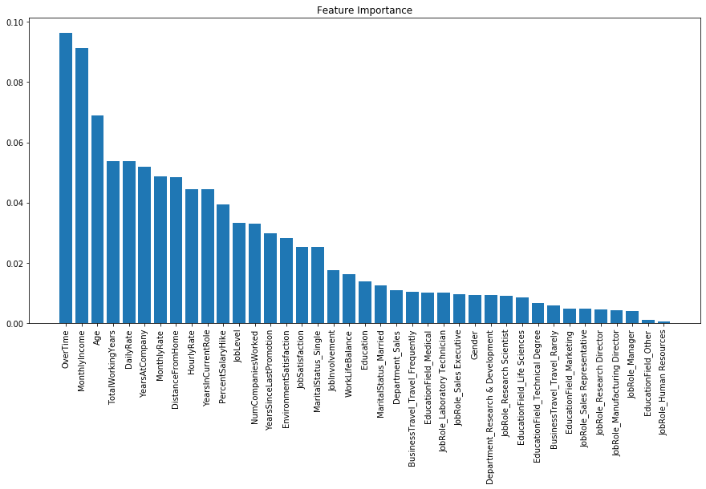

```python
importances = rf_opt.feature_importances_
indices = np.argsort(importances)[::-1] # Sort feature importances in descending order
names = [X_train.columns[i] for i in indices] # Rearrange feature names so they match the sorted feature importances
plt.figure(figsize=(15, 7)) # Create plot
plt.title("Feature Importance") # Create plot title
plt.bar(range(X_train.shape[1]), importances[indices]) # Add bars
plt.xticks(range(X_train.shape[1]), names, rotation=90) # Add feature names as x-axis labels
plt.show() # Show plot
```

```python
importances = rf_opt.feature_importances_
df_param_coeff = pd.DataFrame(columns=['Feature', 'Coefficient'])
for i in range(39):
    feat = X_train.columns[i]
    coeff = importances[i]
    df_param_coeff.loc[i] = (feat, coeff)
df_param_coeff.sort_values(by='Coefficient', ascending=False, inplace=True)
df_param_coeff = df_param_coeff.reset_index(drop=True)
df_param_coeff.head(10)
```

|  | Feature | Coefficient |
| --- | --- | --- |
| 0 | OverTime | 0.096479 |
| 1 | MonthlyIncome | 0.091180 |
| 2 | Age | 0.069052 |
| 3 | TotalWorkingYears | 0.053824 |
| 4 | DailyRate | 0.053737 |
| 5 | YearsAtCompany | 0.052018 |
| 6 | MonthlyRate | 0.048715 |
| 7 | DistanceFromHome | 0.048424 |
| 8 | HourlyRate | 0.044515 |
| 9 | YearsInCurrentRole | 0.044392 |

### Evaluation

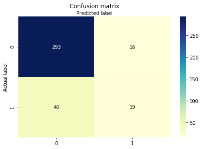

```python
#confusion matrix
cnf_matrix = metrics.confusion_matrix(y_test, rf_opt.predict(X_test))
class_names=[0,1] # name  of classes
fig, ax = plt.subplots()
tick_marks = np.arange(len(class_names))
plt.xticks(tick_marks, class_names)
plt.yticks(tick_marks, class_names)
# create heatmap
sns.heatmap(pd.DataFrame(cnf_matrix), annot=True, cmap="YlGnBu" ,fmt='g')
ax.xaxis.set_label_position("top")
plt.tight_layout()
plt.title('Confusion matrix', y=1.1)
plt.ylabel('Actual label')
plt.xlabel('Predicted label')
```

```python
print('Accuracy of RandomForest Regression Classifier on test set: {:.2f}'.format(rf_opt.score(X_test, y_test)*100))
```

```
Accuracy of RandomForest Regression Classifier on test set: 84.78
```

```python
# Classification report for the optimised RF Regression
rf_opt.fit(X_train, y_train)
print(classification_report(y_test, rf_opt.predict(X_test)))
```

```
              precision    recall  f1-score   support

         0.0       0.88      0.95      0.91       309
         1.0       0.54      0.32      0.40        59

    accuracy                           0.85       368
   macro avg       0.71      0.64      0.66       368
weighted avg       0.83      0.85      0.83       368
```

```python
rf_opt.fit(X_train, y_train) # fit optimised model to the training data
probs = rf_opt.predict_proba(X_test) # predict probabilities
probs = probs[:, 1] # we will only keep probabilities associated with the employee leaving
rf_opt_roc_auc = roc_auc_score(y_test, probs) # calculate AUC score using test dataset
print('AUC score: %.3f' % rf_opt_roc_auc)
```

```
AUC score: 0.785
```

## 8. ROC Graphs

AUC - ROC curve is a performance measurement for classification problem at various thresholds settings. ROC is a probability curve and AUC represents degree or measure of separability. It tells how much model is capable of distinguishing between classes. The green line represents the ROC curve of a purely random classifier; a good classifier stays as far away from that line as possible (toward the top-left corner).

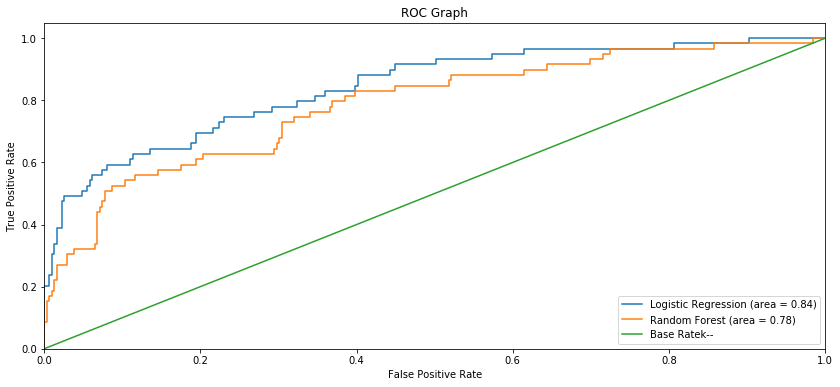

```python
# Create ROC Graph
from sklearn.metrics import roc_curve
fpr, tpr, thresholds = roc_curve(y_test, log_opt.predict_proba(X_test)[:,1])
rf_fpr, rf_tpr, rf_thresholds = roc_curve(y_test, rf_opt.predict_proba(X_test)[:,1])
plt.figure(figsize=(14, 6))

# Plot Logistic Regression ROC
plt.plot(fpr, tpr, label='Logistic Regression (area = %0.2f)' % logit_roc_auc)
# Plot Random Forest ROC
plt.plot(rf_fpr, rf_tpr, label='Random Forest (area = %0.2f)' % rf_opt_roc_auc)
# Plot Base Rate ROC
plt.plot([0,1], [0,1],label='Base Rate' 'k--')

plt.xlim([0.0, 1.0])
plt.ylim([0.0, 1.05])
plt.xlabel('False Positive Rate')
plt.ylabel('True Positive Rate')
plt.title('ROC Graph')
plt.legend(loc="lower right")
plt.show()
```

As shown below, the fine-tuned Logistic Regression model showed a higher AUC score compared to the Random Forest Classifier.

## 9. Conclusion

Hence, we can conclude that active employees with these factors are at more risk of leaving the company.

## Strategic Retention Plan

The stronger indicators of people leaving include:

Monthly Income: people on higher wages are less likely to leave the company. Hence, efforts should be made to gather information on industry benchmarks in the current local market to determine if the company is providing competitive wages.

Over Time: people who work overtime are more likelty to leave the company. Hence efforts must be taken to appropriately scope projects upfront with adequate support and manpower so as to reduce the use of overtime.

Age: Employees in relatively young age bracket 25-35 are more likely to leave. Hence, efforts should be made to clearly articulate the long-term vision of the company and young employees fit in that vision, as well as provide incentives in the form of clear paths to promotion for instance.

Distance From Home: Employees who live further from home are more likely to leave the company. Hence, efforts should be made to provide support in the form of company transportation for clusters of employees leaving the same area, or in the form of Transportation Allowance. Initial screening of employees based on their home location is probably not recommended as it would be regarded as a form of discrimination as long as employees make it to work on time every day.

Total Working Years: The more experienced employees are less likely to leave. Employees who have between 5-8 years of experience should be identified as potentially having a higher-risk of leaving.

Years At Company: Loyal companies are less likely to leave. Employees who hit their two-year anniversary should be identified as potentially having a higher-risk of leaving.

In addition to the suggested steps for each feature listed above, face-to-face meetings between a HR representative and employees can be initiated to discuss work conditions. Also, a meeting with those employee's Line Manager would allow to discuss the work environment within the team and whether steps can be taken to improve it.

## 11. References

www.github.com, www.towardsdatascience.com, www.datacamp.com, www.python.org, www.tutorialspoint.com, https://stackoverflow.com